# Homework 3

## Exercise 4:

One problem with boxplots is that they were developed in an era of much smaller datasets and tend to display a prohibitively large number of “outlying values.” One aproach to remedy this problem is the letter value plot. Install the Ivplot package, and try using geom_lv() to display the distribution of price versus cut. What do you learn? How do you interpret the plots?

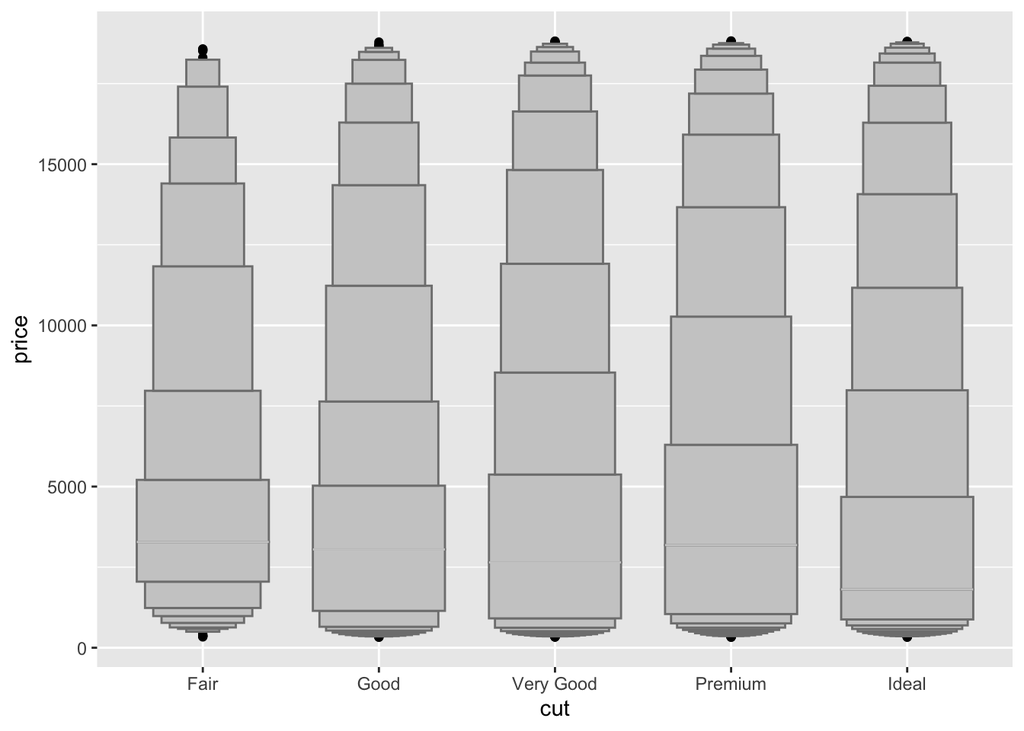

```r
ggplot(diamonds, aes(x = cut, y = price)) +
  geom_lv()
```

They are useful for larger datasets because, larger datasets can give precise estimates of quantiles beyond the quartiles, and in expectation, larger datasets should have more outliers (in absolute numbers).

# Chapter 5 (Pg. 101)

## Exercise 1:

How could you rescale the count dataset to more clearly show the distribution of cut within color, or color within cut?

The count dataset given in the textbook can be rescaled to show the proportion of each cut within a color rather than the raw counts. This can be done by the following chunk of code:

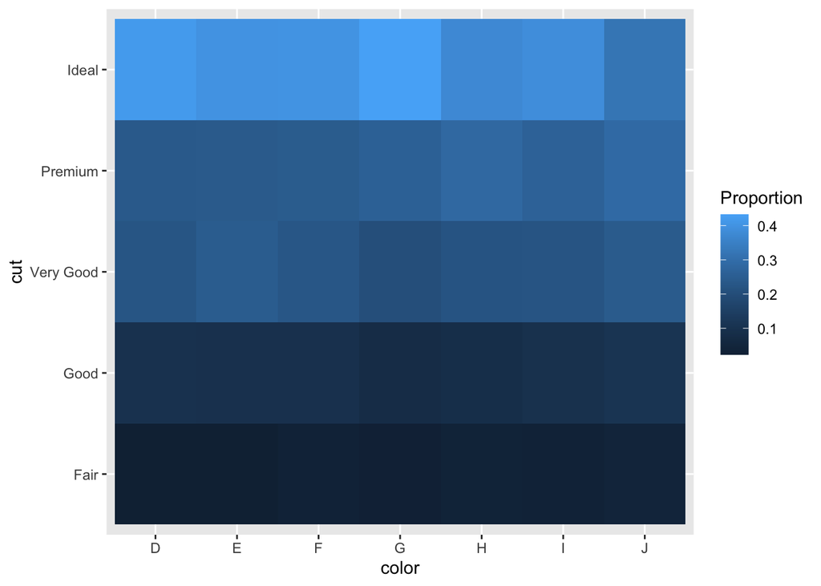

```r
diamonds %>%
  count(color, cut) %>%
  group_by(color) %>%
  mutate(Proportion = n / sum(n)) %>%
  ggplot(mapping = aes(x = color, y = cut)) +
  geom_tile(mapping = aes(fill = Proportion))
```

We can dome something similar to scale the distribution of color within cut.

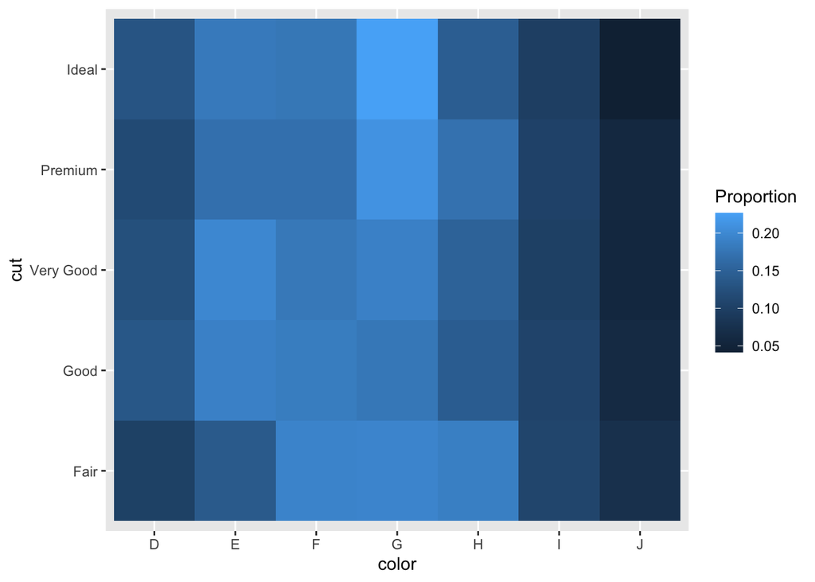

```r
diamonds %>%
  count(color, cut) %>%
  group_by(cut) %>%
  mutate(Proportion = n / sum(n)) %>%
  ggplot(mapping = aes(x = color, y = cut)) +
  geom_tile(mapping = aes(fill = Proportion))
```

## Exercise 2:

Use geom_tile() together with dplyr to explore how average flight delays vary by destination and month of year. What makes the plot difficult to read? How could you improve it?

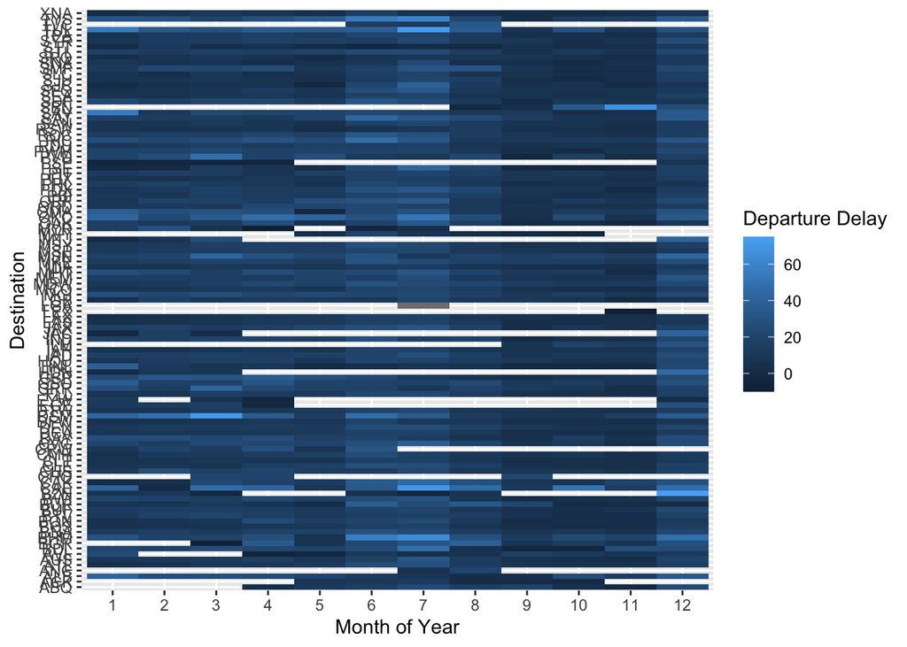

```r
flights %>%
  group_by(month, dest) %>%
  summarise(dep_delay = mean(dep_delay, na.rm = TRUE)) %>%
  ggplot(aes(x = factor(month), y = dest, fill = dep_delay)) +
  geom_tile() +
  labs(x = "Month of Year", y = "Destination", fill = "Departure Delay")
```

It’s hard to tell what the destinations are in the plot, so the plot is hard to read. Something to improve this could be picking fewer destinations to make a plot on. If we really have to make a plot for all the destinations, then we should consider picking a different kind of plot because this information does not play to the strengths of the `geom_tile()` function.

# Chapter 5 (Pg. 104)

## Exercise 2:

Visualize the distribution of carat, partitioned by price.

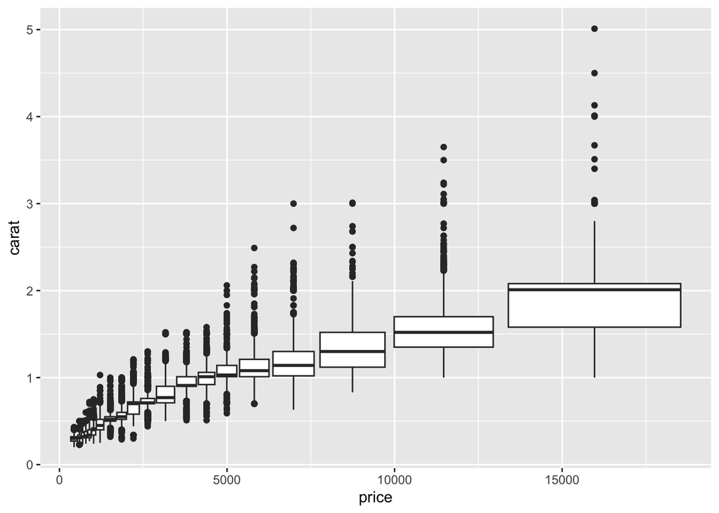

```r
ggplot(diamonds) +
  geom_boxplot(mapping = aes(x = price, y = carat, group = cut_number(price, 20)))
```

## Exercise 3:

How does the price distribution of very large diamonds compare to small diamonds? Is it as you expect, or does it surprise you?

The larger diamonds have a bigger price distribution as compared to smaller diamonds. This was surprising to me at first because I expected the price distribution of diamonds to be independent of their size. Of course larger diamonds sell for more, but they are also a larger distribution with several outliers. But thinking about it after looking the graph makes sense to me because larger diamonds will sell no matter what, but smaller diamonds will share similar characterstics across the other variables to be marketable, hence why they have similar prices.

## Exercise 5:

Two-dimensional plots reveal outliers that are not visible in one-dimensional plots. For example, some points in the following plot have an unusual combination of x and y values, which makes the points outliers even though their x and y values appear normal when examined separately.

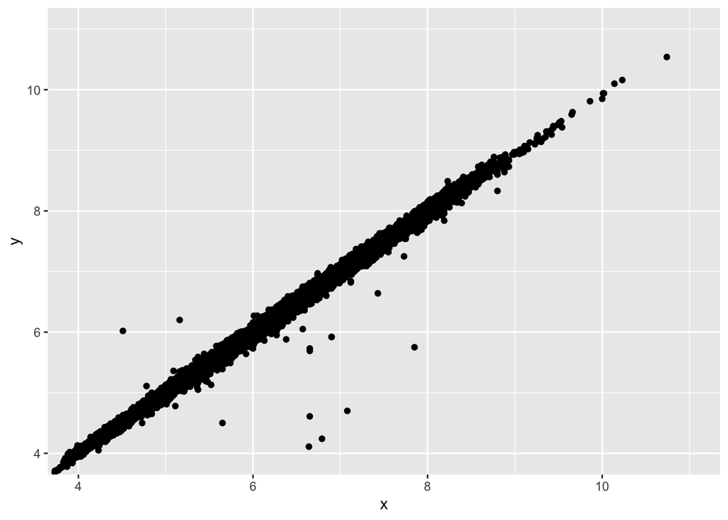

```r
ggplot(data = diamonds) +
  geom_point(mapping = aes(x = x, y = y)) +
  coord_cartesian(xlim = c(4, 11), ylim = c(4, 11))
```

Why is a scatterplot a better display than a binned plot for this case?

A scatterplot is better in this case because we can actually see a very strong linear relationship between x and y. If we were to make a binned plot, we would conclude that the point farthest to the right is an outlier, when in fact it actually fits the pattern really wells and holds the linear relationship. In fact, some of the points between 6 to 8 which lie far away from the line y = x would actually prove to be the outliers that the binned plot wouldn’t show as nicely. That is why a scatter plot is better than a binned plot in this case.